# 00_hipótesis

Profesora Carolina Luque

**Resultado de aprendizaje:** Analiza datos de diversa índole mediante técnicas de estadística descriptiva y probabilidad.

**Hito 3:** Regresión lineal y correlación.

**Temas:**

- ¿Qué es una prueba de hipótesis?
- Pasos para realizar una prueba de hipótesis.

```python
import numpy as np
import matplotlib.pyplot as plt
from scipy.stats import norm
from scipy import stats
from statsmodels.stats.weightstats import ztest
```

# **¿Qué es una prueba de hipótesis?**

Las **pruebas de hipótesis** son una herramienta alternativa para hacer inferencia estadística sobre los parámetros de una población.

En **pruebas de hipótesis** se busca **rechazar** o **no rechazar** una afirmación acerca de una **característica de la población**, con base en la **información de una muestra aleatoria** de la población.

### **Hipótesis estadística** ($H$):

Es una **afirmación sobre la distribución de la población**, que comúnmente se expresa por medio de un parámetro $\theta\in\Theta$, donde $\Theta$ es el conjunto de todos los posibles valores que puede asumir $\theta$.

**Ejemplos**:

- Si $\theta = \mu$, entonces $\Theta=\mathbb{R}$.
- Si $\theta = \sigma^2$, entonces $\Theta = \mathbb{R}^+$.
- Si $\theta = \pi$, entonces $\Theta = (0,1)$.

# **Pasos para realizar una prueba de hipótesis**

Para **probar una hipótesis estadística**, se utiliza el método científico:

1. Establecer el **estado actual del conocimiento** (statu quo).
2. Proponer un **sistema de hipótesis estadísticas**.
3. Observar una **muestra aleatoria** (experimentar).
4. Analizar los **resultados** respecto a las hipótesis bajo consideración.
- Fijar un nivel de significancia.
- Establecer valor crítico - región de crítica
- Determinar un estadístico de prueba - calcular el valor p
5. Tomar **decisiones** con base en los datos obtenidos. Interpretar los resultados para saber si se debe rechazar o no la hipótesis actual.

## **Sistema de hipótesis**

**Hipótesis nula** ($H_0$): hipótesis que refleja el **estado actual de conocimiento de la población**. Es la hipótesis que al final del protocolo se debe **rechazar** o **no rechazar**. $$ H_0: \theta\in\Theta_0\qquad \text{donde $\Theta_0\subset\Theta$.} $$

**Hipótesis alternativa** ($H_1$): hipótesis **sobre la cual se quiere encontrar evidencia empírica**. $$ H_1: \theta\in\Theta_1\qquad\text{donde $\Theta_1\subseteq\Theta$ y $\Theta_0\cap\Theta_1=\emptyset$.} $$

**Sistema de hipótesis**: pareja de hipótesis conformada por la hipótesis nula y la hipótesis alternativa.

$$H_0: \theta\in\Theta_0\qquad \text{frente a}\qquad H_1: \theta\in\Theta_1\,.$$

### **Ejemplo: demanda de un producto**

Una empresa que distribuye un producto tiene un historial de **demanda promedio de 40 unidades**. No obstante, tras el reciente lanzamiento de una campaña, se han observado fluctuaciones en las ventas. La empresa quiere evaluar si **la demanda promedio ha cambiado significativamente** a raíz de la campaña. ¿Deberían continuar invirtiendo en la campaña?

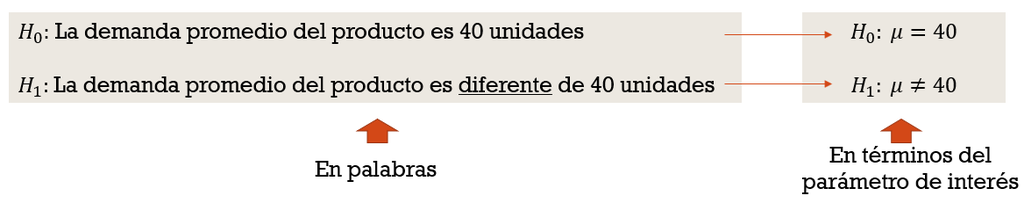

```python
# valor bajo la hipótesis nula
mu_0 = 40
```

**Test** ($\tau$): **regla**, **norma**, **procedimiento** o **protocolo** que permite tomar una decisión (rechazar $H_0$ o no rechazar $H_0$).

**Observaciones**:

- Las hipótesis son **afirmaciones acerca de la población**, que por lo general se expresan por medio de los **parámetros de la población**.
- El objetivo consiste en establecer si existe **suficiente evidencia** en la **realización de una muestra aleatoria** para **rechazar** $H_0$ o **no rechazar** $H_0$, es decir, identificar **cuál es la hipótesis que mejor explica los datos observados**.

### **Alternativas para plantear el sistema de hipótesis**

$$ \begin{array}{|c|c|c|c|} \hline \textbf{Hipótesis Nula} & H_0: \mu = \mu_0 & H_0: \mu \geq \mu_0 & H_0: \mu \leq \mu_0 \\ \hline \textbf{Hipótesis Alternativa} & H_1: \mu \neq \mu_0 & H_1: \mu < \mu_0 & H_1: \mu > \mu_0 \\ \hline \end{array} $$

## **Muestra aleatoria**

### **Ejemplo: demanda de un producto**

La empresa ha tomado una muestra aleatoria de los últimos 100 días y ha registrado las demandas diarias. A continuación, están los datos de las demandas en unidades:

```python
# datos de ejemplo (demandas en los últimos 100 días)
demandas = [42, 30, 41, 46, 40, 37, 39, 40, 55, 37, 43, 38, 41, 36, 36, 54,
            39, 44, 39, 38, 40, 37, 42, 40, 42, 39, 41, 43, 39, 40, 44, 41,
            36, 38, 38, 44, 37, 32, 41, 36, 40, 43, 41, 38, 42, 39, 41, 40,
            39, 38, 43, 41, 48, 42, 39, 38, 43, 40, 39, 40, 39, 43, 47, 42,
            40, 47, 41, 48, 43, 42, 38, 44, 40, 39, 36, 39, 40, 42, 41, 43,
            38, 34, 39, 40, 36, 43, 41, 37, 39, 42, 40, 38, 44, 50, 42, 49,
            50, 42, 40, 35]
```

```python
# información de la muestra
n = len(demandas)
media = np.mean(demandas)
desviacion_estandar = np.std(demandas)

print(f"Tamaño de muestra: {n}")
print(f"Media: {media}")
print(f"Desviación estándar: {desviacion_estandar}")
```

```
Tamaño de muestra: 100
Media: 40.72
Desviación estándar: 3.9346664407545395
```

## **Tipos de errores**

Cuando se hace una prueba de hipótesis podría ocurrir que la muestra no dé evidencias acerca de lo que ocurre en la población:

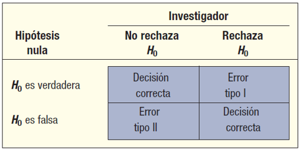

El **error tipo I** consiste en **rechazar la hipótesis nula, cuando ésta es cierta**.

La **probabilidad de cometer el error tipo I** se llama **nivel de significancia** ($\alpha$) y **se fija antes de iniciar el estudio**:

$$\alpha = \textsf{Pr}(\text{Rechazar }H_0\mid H_0\text{ es cierta})$$

El complemento de $\alpha$ es la **confiabilidad**:

$$1-\alpha = \textsf{Pr}(\text{No rechazar }H_0\mid H_0\text{ es cierta})$$

El **error tipo II** consiste en **no rechazar la hipótesis nula, cuando ésta es falsa**.

La **probabilidad de cometer el error tipo II** se llama **función característica** ($\beta(\theta)$) porque se puede calcular para cada $\theta\in\Theta_1$:

$$\beta(\theta)=\textsf{Pr}(\text{No rechazar }H_0\mid H_0\text{ es falsa})$$

El complemento de $\beta(\theta)$ se llama **función de potencia**:

$$\pi(\theta)=1-\beta(\theta) = \textsf{Pr}(\text{Rechazar }H_0\mid H_0\text{ es falsa})$$

### **Ejemplo: demanda de un producto**

- **Error Tipo I ($\alpha$)**: *Este error ocurre cuando se concluye que la demanda promedio ha cambiado significativamente respecto a las 40 unidades, cuando en realidad no lo ha hecho*.

  En este caso, se tomaría una decisión incorrecta al suponer que la campaña ha afectado la demanda, cuando la media sigue siendo de 40 unidades. Esto podría llevar a seguir gastando recursos en una campaña que no está funcionando.
- **Error Tipo II ($\beta$)**: *Este error implica no detectar un cambio en la demanda promedio cuando efectivamente ha ocurrido*.

  Esto significa asumir incorrectamente que la demanda sigue siendo de 40 unidades, a pesar de que ha cambiado como resultado de la campaña. Como consecuencia, se podría descartar una campaña que está generando resultados positivos, lo que implicaría perder oportunidades de crecimiento y no estar preparados para satisfacer las necesidades del mercado actual.

## **Nivel de significancia**

El nivel de significancia, generalmente denotado como $\alpha$, es un umbral que **se establece antes de realizar un análisis estadístico** para decidir cuándo rechazar la hipótesis nula.

- $\alpha = 0.05$: es el nivel más utilizado. Indica que hay un 5% de probabilidad de rechazar la hipótesis nula cuando es verdadera.
- $\alpha = 0.01$: utilizado en estudios donde se requiere una mayor certeza.
- $\alpha = 0.10$: utilizado en investigaciones donde se acepta un mayor riesgo de error.

```python
# nivel de significancia
alpha = 0.05
```

## **Valor crítico y región crítica**

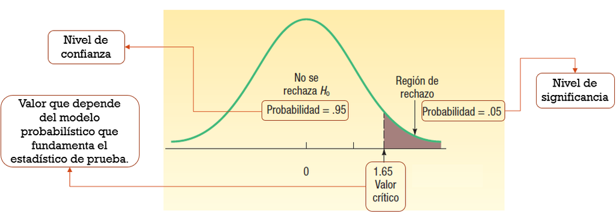

### **Ejemplo: demanda de un producto**

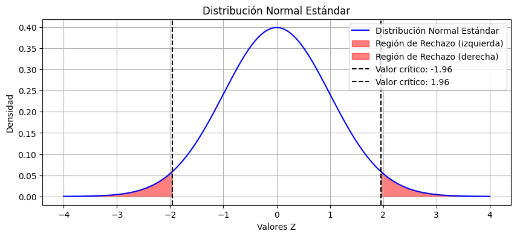

```python
# parámetros
alpha = 0.05
z_critico = norm.ppf(1 - alpha/2)  # valor crítico para una prueba bilateral

# valores para la gráfica
x = np.linspace(-4, 4, 1000)
y = norm.pdf(x)  # Densidad de probabilidad

# graficar la distribución normal
plt.figure(figsize=(10, 4))
plt.plot(x, y, label='Distribución Normal Estándar', color='blue')

# sombrear las regiones de rechazo
plt.fill_between(x, y, where=(x <= -z_critico), color='red', alpha=0.5, label='Región de Rechazo (izquierda)')
plt.fill_between(x, y, where=(x >= z_critico), color='red', alpha=0.5, label='Región de Rechazo (derecha)')

# líneas de los valores críticos
plt.axvline(-z_critico, color='black', linestyle='--', label=f'Valor crítico: {round(-z_critico, 2)}')
plt.axvline(z_critico, color='black', linestyle='--', label=f'Valor crítico: {round(z_critico, 2)}')

# personalizar la gráfica
plt.title('Distribución Normal Estándar')
plt.xlabel('Valores Z')
plt.ylabel('Densidad')
plt.legend()
plt.grid()

# mostrar la gráfica
plt.show()
```

## **Estadístico de prueba y valor p**

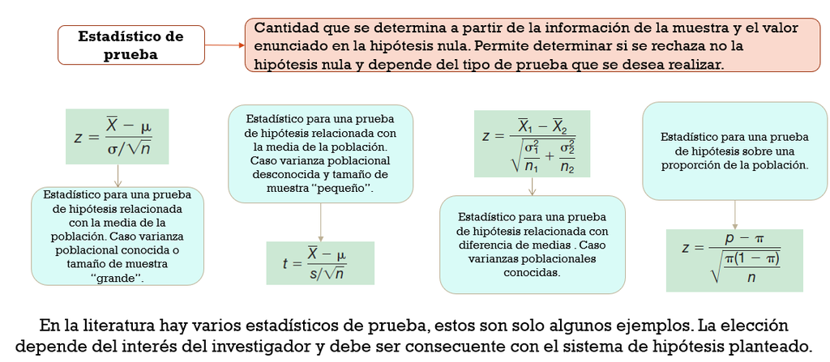

El **valor $p$** se define como

$$ p = \textsf{Pr}(\text{Observar datos tan o más extremos en dirección de } H_1\mid H_0\text{ es cierta}) $$

El test consiste en:

$$\tau:\text{Rechazar }H_0\text{ si el valor }p<\alpha$$

### **Ejemplo: demanda de un producto**

```python
# calcular el estadístico de prueba
z = (media - mu_0) / (desviacion_estandar / np.sqrt(n))

print(f"Valor del estadístico de prueba (z): {z}")
```

```
Valor del estadístico de prueba (z): 1.8298882785650479
```

```python
# p-valor (bilateral)
p_valor = 2 * (1 - norm.cdf(abs(z)))

print(f"p-valor: {p_valor}")
```

```
p-valor: 0.06726664653535219
```

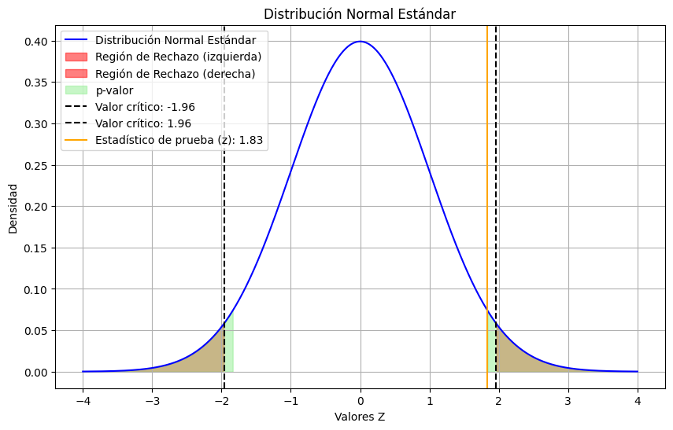

```python
# valores para la gráfica
x = np.linspace(-4, 4, 1000)
y = norm.pdf(x)  # Densidad de probabilidad

# graficar la distribución normal
plt.figure(figsize=(10, 6))
plt.plot(x, y, label='Distribución Normal Estándar', color='blue')

# sombrear las regiones de rechazo
plt.fill_between(x, y, where=(x <= -z_critico), color='red', alpha=0.5, label='Región de Rechazo (izquierda)')
plt.fill_between(x, y, where=(x >= z_critico), color='red', alpha=0.5, label='Región de Rechazo (derecha)')

# sombrear el p-valor en ambas colas
plt.fill_between(x, y, where=(x <= -abs(z)), color='lightgreen', alpha=0.5, label='p-valor')
plt.fill_between(x, y, where=(x >= abs(z)), color='lightgreen', alpha=0.5)

# líneas de los valores críticos
plt.axvline(-z_critico, color='black', linestyle='--', label=f'Valor crítico: {round(-z_critico, 2)}')
plt.axvline(z_critico, color='black', linestyle='--', label=f'Valor crítico: {round(z_critico, 2)}')

# línea del estadístico de prueba
plt.axvline(z, color='orange', linestyle='-', label=f'Estadístico de prueba (z): {round(z, 2)}')

# personalizar la gráfica
plt.title('Distribución Normal Estándar')
plt.xlabel('Valores Z')
plt.ylabel('Densidad')
plt.legend()
plt.grid()

# mostrar la gráfica
plt.show()
```

```python
# alternativa 1: paso a paso

# valor bajo la hipótesis: nula mu_0
# significancia: alpha = 0.05
# información de la muestra: tamaño de muestra, media, desviación estándar

# estadístico Z
z_statistic = (media - mu_0) / (desviacion_estandar / np.sqrt(n))

# valor p para la prueba Z
p_value = 2 * (1 - norm.cdf(abs(z)))

# mostrar resultados
print(f'Estadístico Z: {z_statistic:.4f}')
print(f'Valor p: {p_value:.4f}')

# decisión de rechazar o no la hipótesis nula (nivel de significancia = 0.05)
alpha = 0.05
if p_value < alpha:
    print("Rechazar la hipótesis nula (H₀)")
else:
    print("No se rechaza la hipótesis nula (H₀)")
```

```
Estadístico Z: 1.8299
Valor p: 0.0673
No se rechaza la hipótesis nula (H₀)
```

```python
# alternativa 2: utilizando el método ztest - from statsmodels.stats.weightstats import ztest

# realizar la prueba Z
z_statistic, p_value_bilateral = ztest(demandas, value=mu_0, alternative='two-sided', ddof=0)

# mostrar resultados
print(f'Estadístico Z: {z_statistic:.4f}')
print(f'Valor p: {p_value_bilateral:.4f}')

# decisión de rechazar o no la hipótesis nula (nivel de significancia = 0.05)
alpha = 0.05
if p_value < alpha:
    print("Rechazar la hipótesis nula (H₀)")
else:
    print("No se rechaza la hipótesis nula (H₀)")
```

```
Estadístico Z: 1.8299
Valor p: 0.0673
No se rechaza la hipótesis nula (H₀)
```

```python
# prueba de hipótesis unilateral a derecha

# realizar la prueba Z
z_statistic, p_value_bilateral = ztest(demandas, value=mu_0, alternative='larger', ddof=0) # para una prueba a izquierda alternative='smaller'

# mostrar resultados
print(f'Estadístico Z: {z_statistic:.4f}')
print(f'Valor p: {2*p_value:.4f}')

# decisión de rechazar o no la hipótesis nula (nivel de significancia = 0.05)
alpha = 0.05
if 2*p_value < alpha:
    print("Rechazar la hipótesis nula (H₀)")
else:
    print("No se rechaza la hipótesis nula (H₀)")
```

[output not shown]

## **Tomar decisiones**

### **Ejemplo: demanda de un producto**

Con un nivel de significancia del 5%, se concluye que en la muestra no hay evidencia suficiente para rechazar la hipótesis nula. Por lo tanto, las fluctuaciones en las ventas no constituyen evidencia suficiente para afirmar que la demanda promedio ha cambiado significativamente a raíz de la campaña. En consecuencia, es razonable concluir que, según los datos actuales, la campaña puede no estar generando el impacto deseado y podría no justificar una mayor inversión en su formato actual.

# **Referencias**

- Igual, L. and Seguí, S. (2017). Introduction to Data Science A Python Approach to Concepts, Techniques and Applications. Springer.
- Haslwanter, T. (2016). An Introduction to Statistics with Python With Applications in the Life Sciences. Springer.
- Sosa, J., Ospina, L. E. and Berdugo, E. P. (2013). Estadística descriptiva y probabilidades. Universidad Externado de Colombia. ISBN/ISSN: 978-958-772-070-9.
- Rajagopalan, G. (2021). A Python Data Analyst's Toolkit: Learn Python and Python-based Libraries with Applications in Data Analysis and Statistics. Springer.